# Introduction et Concepts de base

# Prise en Main

## Comme une calculatrice:

- Vous voyez l’opérateur d’assignation `<-` :

```r
a <- 2+2
b <- 5-7
c <- 4*12
d <- 10/3
e <- 5^2
Resultat <- a + b + c +d +e

Text <- "Hello students, the result is "
```

Rmarkdown permet combiner text et code: Hello students, the result is 78.3333333

- Les noms d’objets peuvent contenir des lettres, des chiffres, les symboles `.` et `_`.
- Ils ne peuvent pas commencer par un chiffre.
- R fait la différence entre minuscules et majuscules dans les noms d’objets, ce qui signifie que `x` et `X` seront deux objets différents, tout comme `resultat` et `Resultat`.

Conseils:

- Il est préférable d’éviter les majuscules (pour les risques d’erreur) et les caractères accentués (pour des questions d’encodage) dans les noms d’objets.
- De même, il faut essayer de trouver un équilibre entre clarté du nom (comprendre à quoi sert l’objet, ce qu’il contient) et sa longueur. Par exemple, on préfèrera comme nom d’objet `taille_conj1` à `taille_du_conjoint_numero_1` (trop long) ou à `t1` (pas assez explicite).

### Vecteurs

Imaginons maintenant qu’on a demandé la taille en centimètres de 5 personnes et qu’on souhaite calculer leur taille moyenne.

On pourrait créer autant d’objets que de tailles et faire l’opération mathématique qui va bien :

```r
taille1 <- 156
taille2 <- 164
taille3 <- 197
taille4 <- 147
taille5 <- 173
(taille1 + taille2 + taille3 + taille4 + taille5) / 5
```

```
## [1] 167.4
```

Cette manière de faire n’est évidemment pas pratique du tout. On va plutôt stocker l’ensemble de nos tailles dans un seul objet, de type *vecteur*, avec la syntaxe suivante:

```r
tailles <- c(156, 164, 197, 147, 173)
tailles
```

```
## [1] 156 164 197 147 173
```

```r
# Taille en metres
tailles_m <- tailles / 100
tailles_m
```

```
## [1] 1.56 1.64 1.97 1.47 1.73
```

```r
#Cela fonctionne pour toutes les opérations de base :

tailles + 10
```

```
## [1] 166 174 207 157 183
```

```r
tailles^2
```

```
## [1] 24336 26896 38809 21609 29929
```

L’avantage d’un vecteur est que lorsqu’on lui applique une opération, celle-ci s’applique à toutes les valeurs qu’il contient.

Imaginons maintenant qu’on a aussi demandé aux cinq mêmes personnes leur poids en kilos. On peut alors créer un deuxième vecteur :

```r
poids <- c(45, 59, 110, 44, 88)
```

On peut alors effectuer des calculs utilisant nos deux vecteurs `tailles` et `poids`.

On peut par exemple calculer l’indice de masse corporelle (IMC) de chacun de nos enquêtés en divisant leur poids en kilo par leur taille en mètre au carré :

```r
# option 1
imc <- poids / (tailles / 100) ^ 2
imc
```

```
## [1] 18.49112 21.93635 28.34394 20.36189 29.40292
```

```r
# option 2
imc <- poids / (tailles_m) ^ 2
imc
```

```
## [1] 18.49112 21.93635 28.34394 20.36189 29.40292
```

Un vecteur peut contenir des nombres, mais il peut aussi contenir du texte.

Imaginons qu’on a demandé aux 5 mêmes personnes leur niveau de diplôme : on peut regrouper l’information dans un vecteur de *chaînes de caractères*. Une chaîne de caractère contient du texte libre, délimité par des guillemets simples ou doubles :

```r
diplome <- c("CAP", "Bac", "Bac+2", "CAP", "Bac+3")
diplome
```

```
## [1] "CAP"   "Bac"   "Bac+2" "CAP"   "Bac+3"
```

### Opérateur `[]`

L’opérateur `[]`, permet donc la sélection d’éléments d’un vecteur. On peut accéder à un élément particulier d’un vecteur en faisant suivre le nom du vecteur de crochets contenant le numéro de l’élément désiré. Par exemple :

```r
diplome[1]
```

```
## [1] "CAP"
```

```r
diplome[2]
```

```
## [1] "Bac"
```

```r
#diplome[c(1,2,3)]
```

### L’opérateur `:`

Il permet de générer rapidement un vecteur comprenant tous les nombres entre deux valeurs, opération assez courante sous R :

```r
diplome[1:3]
```

```
## [1] "CAP"   "Bac"   "Bac+2"
```

```r
# Vecteurs très longes
x <- 1:200
x
```

```
##   [1]   1   2   3   4   5   6   7   8   9  10  11  12  13  14  15  16  17  18
##  [19]  19  20  21  22  23  24  25  26  27  28  29  30  31  32  33  34  35  36
##  [37]  37  38  39  40  41  42  43  44  45  46  47  48  49  50  51  52  53  54
##  [55]  55  56  57  58  59  60  61  62  63  64  65  66  67  68  69  70  71  72
##  [73]  73  74  75  76  77  78  79  80  81  82  83  84  85  86  87  88  89  90
##  [91]  91  92  93  94  95  96  97  98  99 100 101 102 103 104 105 106 107 108
## [109] 109 110 111 112 113 114 115 116 117 118 119 120 121 122 123 124 125 126
## [127] 127 128 129 130 131 132 133 134 135 136 137 138 139 140 141 142 143 144
## [145] 145 146 147 148 149 150 151 152 153 154 155 156 157 158 159 160 161 162
## [163] 163 164 165 166 167 168 169 170 171 172 173 174 175 176 177 178 179 180
## [181] 181 182 183 184 185 186 187 188 189 190 191 192 193 194 195 196 197 198
## [199] 199 200
```

Des questions?…

### Fonctions

- Deuxième concept de base de R.
- On utilise des fonctions pour effectuer des calculs, obtenir des résultats et accomplir des actions.
- Une fonction a:
  1. un *nom*,
  2. Elle prend en entrée entre parenthèses un ou plusieurs *arguments* (ou *paramètres*), 3.Retourne un *résultat*.

Exemple: Si on veut connaître le nombre d’éléments du vecteur `tailles` que nous avons construit précédemment, on peut utiliser la fonction `length`, de cette manière :

```r
length(tailles)
```

```
## [1] 5
```

```r
min(tailles)
```

```
## [1] 147
```

```r
max(tailles)
```

```
## [1] 197
```

```r
sum(tailles)
```

```
## [1] 837
```

```r
mean(tailles)
```

```
## [1] 167.4
```

```r
range(tailles)
```

```
## [1] 147 197
```

```r
# Voir l'aide des fonctions
?length
?max
help("mean")
```

- `length`: est le nom de la fonction, on l’appelle en lui passant un argument entre parenthèses (en l’occurrence notre vecteur `tailles`), et elle nous renvoie un résultat, à savoir le nombre d’éléments du vecteur passé en paramètre.
- `min` et `max` retournent respectivement les valeurs minimales et maximales d’un vecteur de nombres.
- `mean`: calcule et retourne la moyenne d’un vecteur de nombres :
- `sum` retourne la somme de tous les éléments du vecteur :
- `range` (étendue) renvoie un vecteur de deux nombres, le minimum et le maximum :

```r
diplome <- c("CAP", "Bac", "Bac+2", "CAP", "Bac+3")
unique(diplome)
```

```
## [1] "CAP"   "Bac"   "Bac+2" "Bac+3"
```

```r
nchar(diplome)
```

```
## [1] 3 3 5 3 5
```

- `unique`, qui supprime toutes les valeurs en double dans un vecteur, qu’il s’agisse de nombres ou de chaînes de caractères :

### Arguments

- Une fonction peut prendre plusieurs arguments, dans ce cas on les indique toujours entre parenthèses, séparés par des virgules.
- Un exemple de fonction acceptant plusieurs arguments : la fonction `c`, qui combine l’ensemble de ses arguments en un vecteur[^1] :

```r
tailles <- c(156, 164, 197, 181, 173)
```

Ici, `c` est appelée en lui passant cinq arguments, les cinq tailles séparées par des virgules, et elle renvoie un vecteur numérique regroupant ces cinq valeurs.

Supposons maintenant que dans notre vecteur `tailles` nous avons une valeur manquante (une personne a refusé de répondre, ou notre mètre mesureur était en panne). On symbolise celle-ci dans R avec le code interne `NA` :

```r
tailles <- c(156, 164, 197, NA, 173)
tailles
```

```
## [1] 156 164 197  NA 173
```

`NA` est l’abbréviation de *Not available*, non disponible. Cette valeur particulière peut être utilisée pour indiquer une valeur manquante, qu’il s’agisse d’un nombre, d’une chaîne de caractères, etc.

Si je calcule maintenant la taille moyenne à l’aide de la fonction `mean`, j’obtiens :

```r
# Il considère alors que cette moyenne est elle-même "non disponible" et renvoie donc comme résultat `NA`.
mean(tailles)
```

```
## [1] NA
```

```r
# Ceci se fait en ajoutant un argument supplémentaire, nommé `na.rm` (abbréviation de *NA remove*, "enlever les NA"), et de lui attribuer la valeur `TRUE` (code interne de R signifiant *vrai*) :

mean(tailles, na.rm = TRUE)
```

```
## [1] 172.5
```

Lorsqu’on passe un argument à une fonction de cette manière, c’est-à-dire sous la forme `nom = valeur`, on parle d’*argument nommé*.

## Packages

R étant un logiciel libre, il bénéficie d’un développement communautaire riche et dynamique.

L’installation de base de R permet de faire énormément de choses, mais le langage dispose en plus d’un système d’extensions permettant d’ajouter facilement de nouvelles fonctionnalités. La plupart des extensions sont développées et maintenues par la communauté des utilisateurs de R, et diffusées via un réseau de serveurs nommé CRAN (Comprehensive R Archive Network).

```r
# Options 1
install.packages("questionr")
install.packages("tidyverse")

# Option 2 --> Paneau
```

il faut la “charger” avant de pouvoir utiliser les fonctions qu’elle propose. Ceci se fait avec la fonction `library`.

```r
library(questionr)
library(tidyverse)
```

Prenons une Pause de 10 min !!!

## Tableau de Données (Data Frames)

L’utilisation de `library` permet de rendre “disponibles”, dans notre session R, les fonctions et jeux de données inclus dans l’extension.

Nous devons ensuite indiquer à R que nous souhaitons accéder au jeu de données à l’aide de la commande `data` :

```r
data(hdv2003)

# Voir les donnes
hdv2003
```

```
##        id age  sexe
## 1       1  28 Femme
## 2       2  23 Femme
## 3       3  59 Homme
## 4       4  34 Homme
## 5       5  71 Femme
## 6       6  35 Femme
## 7       7  60 Femme
## 8       8  47 Homme
## 9       9  20 Femme
## 10     10  28 Homme
## 11     11  65 Femme
## 12     12  47 Homme
## 13     13  63 Femme
## 14     14  67 Femme
```

[output cut: 11991 more lines]

```r
# Voir (mieux) les donnes
View(hdv2003)

# Assigne une variable à un data frame.
enquete <- hdv2003
```

### Exploration du data frame:

```r
# Nombre des lignes
nrow(enquete)
```

```
## [1] 2000
```

```r
# Nombre de colonnes
ncol(enquete)
```

```
## [1] 20
```

```r
# Or
dim(enquete)
```

```
## [1] 2000   20
```

```r
# Noms des colonnes
names(enquete)
```

```
##  [1] "id"            "age"           "sexe"          "nivetud"
##  [5] "poids"         "occup"         "qualif"        "freres.soeurs"
##  [9] "clso"          "relig"         "trav.imp"      "trav.satisf"
## [13] "hard.rock"     "lecture.bd"    "peche.chasse"  "cuisine"
## [17] "bricol"        "cinema"        "sport"         "heures.tv"
```

```r
# Structure du tableau
str(enquete)
```

```
## 'data.frame':    2000 obs. of  20 variables:
##  $ id           : int  1 2 3 4 5 6 7 8 9 10 ...
##  $ age          : int  28 23 59 34 71 35 60 47 20 28 ...
##  $ sexe         : Factor w/ 2 levels "Homme","Femme": 2 2 1 1 2 2 2 1 2 1 ...
##  $ nivetud      : Factor w/ 8 levels "N'a jamais fait d'etudes",..: 8 NA 3 8 3 6 3 6 NA 7 ...
##  $ poids        : num  2634 9738 3994 5732 4329 ...
##  $ occup        : Factor w/ 7 levels "Exerce une profession",..: 1 3 1 1 4 1 6 1 3 1 ...
##  $ qualif       : Factor w/ 7 levels "Ouvrier specialise",..: 6 NA 3 3 6 6 2 2 NA 7 ...
##  $ freres.soeurs: int  8 2 2 1 0 5 1 5 4 2 ...
##  $ clso         : Factor w/ 3 levels "Oui","Non","Ne sait pas": 1 1 2 2 1 2 1 2 1 2 ...
##  $ relig        : Factor w/ 6 levels "Pratiquant regulier",..: 4 4 4 3 1 4 3 4 3 2 ...
##  $ trav.imp     : Factor w/ 4 levels "Le plus important",..: 4 NA 2 3 NA 1 NA 4 NA 3 ...
##  $ trav.satisf  : Factor w/ 3 levels "Satisfaction",..: 2 NA 3 1 NA 3 NA 2 NA 1 ...
##  $ hard.rock    : Factor w/ 2 levels "Non","Oui": 1 1 1 1 1 1 1 1 1 1 ...
##  $ lecture.bd   : Factor w/ 2 levels "Non","Oui": 1 1 1 1 1 1 1 1 1 1 ...
##  $ peche.chasse : Factor w/ 2 levels "Non","Oui": 1 1 1 1 1 1 2 2 1 1 ...
##  $ cuisine      : Factor w/ 2 levels "Non","Oui": 2 1 1 2 1 1 2 2 1 1 ...
##  $ bricol       : Factor w/ 2 levels "Non","Oui": 1 1 1 2 1 1 1 2 1 1 ...
##  $ cinema       : Factor w/ 2 levels "Non","Oui": 1 2 1 2 1 2 1 1 2 2 ...
##  $ sport        : Factor w/ 2 levels "Non","Oui": 1 2 2 2 1 2 1 1 1 2 ...
##  $ heures.tv    : num  0 1 0 2 3 2 2.9 1 2 2 ...
```

### L’opérateur `$`

Une opération très importante est l’accès aux variables du tableau (à ses colonnes) pour pouvoir les manipuler, effectuer des calculs, etc.

On utilise pour cela l’opérateur `$`, qui permet d’accéder aux colonnes du tableau.

```r
enquete$sexe
```

```
##    [1] Femme Femme Homme Homme Femme Femme Femme Homme Femme Homme Femme Homme
##   [13] Femme Femme Femme Femme Homme Femme Homme Femme Femme Homme Femme Femme
##   [25] Femme Homme Femme Homme Homme Homme Homme Homme Homme Homme Femme Femme
##   [37] Homme Femme Femme Homme Femme Homme Homme Femme Femme Homme Femme Femme
##   [49] Femme Femme Homme Femme Homme Femme Homme Femme Femme Femme Homme Femme
##   [61] Femme Homme Homme Homme Homme Femme Homme Homme Femme Femme Homme Homme
##   [73] Femme Femme Femme Femme Homme Femme Femme Femme Femme Femme Femme Homme
##   [85] Homme Femme Homme Homme Homme Homme Homme Femme Homme Femme Femme Femme
##   [97] Homme Homme Femme Femme Femme Homme Femme Homme Homme Femme Femme Femme
##  [109] Femme Homme Homme Homme Homme Homme Femme Homme Homme Femme Homme Homme
##  [121] Femme Femme Femme Homme Femme Femme Homme Femme Femme Homme Femme Homme
##  [133] Femme Femme Femme Homme Homme Homme Homme Homme Homme Homme Homme Femme
##  [145] Homme Homme Homme Femme Femme Femme Homme Femme Femme Femme Femme Homme
##  [157] Femme Homme Homme Homme Femme Homme Femme Homme Femme Homme Homme Femme
##  [169] Femme Femme Homme Femme Homme Femme Femme Femme Homme Homme Homme Femme
```

[output cut: 153 more lines]

Afficher seulement les premières ou dernières valeurs d’une variable, on peut utiliser les fonctions `head` et `tail` :

```r
head(enquete$age, 10)
```

```
##  [1] 28 23 59 34 71 35 60 47 20 28
```

```r
tail(enquete$age, 10)
```

```
##  [1] 52 42 50 41 46 45 46 24 24 66
```

### Creer de nouvelle vecteurs `$`

On peut aussi utiliser l’opérateur `$` pour créer une nouvelle variable dans notre tableau : pour cela, il suffit de lui assigner une valeur.

```r
# Par exemple, la variable `heures.tv` contient le nombre d'heures passées quotidiennement devant la télé :

head(enquete$heures.tv, 10)
```

```
##  [1] 0.0 1.0 0.0 2.0 3.0 2.0 2.9 1.0 2.0 2.0
```

```r
# Nouvelle variable dans notre tableau qui contienne la même durée mais en minutes.

enquete$minutes.tv <- enquete$heures.tv * 60

# Constate la nouvelle variable
head(enquete$minutes.tv)
```

```
## [1]   0  60   0 120 180 120
```

## Introduction à la visualisation des donnés

### Indicateurs de centralité

Pour cela on peut commencer par regarder les valeurs extrêmes, avec les fonctions min, max ou range :

```r
# Valeurs descriptives de centralité
min(enquete$age)
```

```
## [1] 18
```

```r
max(enquete$age)
```

```
## [1] 97
```

```r
range(enquete$age)
```

```
## [1] 18 97
```

```r
# Moyenne vs Médian
mean(enquete$age)
```

```
## [1] 48.157
```

```r
median(enquete$age)
```

```
## [1] 48
```

```r
#Une différence entre les deux indicateurs est que la médiane est beaucoup moins sensible aux valeurs “extrêmes” : on dit qu’elle est plus robuste. Ainsi, en 2013, le salaire net moyen des salariés à temps plein en France était de 2202 euros, tandis que le salaire net médian n’était que de 1772 euros. La différence étant due à des très hauts salaires qui “tirent” la moyenne vers le haut.
```

### Indicateurs de Dispersion

Les indicateurs de dispersion permettent de mesurer si les valeurs sont plutôt regroupées ou au contraire plutôt dispersées.

```r
max(enquete$age) - min(enquete$age)
```

```
## [1] 79
```

```r
# Variance
var(enquete$age)
```

```
## [1] 287.0249
```

```r
# L’écart-type (standard deviation)
sd(enquete$age)
```

```
## [1] 16.94181
```

```r
# Variance ou, de manière équivalente, l’écart-type (qui est égal à la racine carrée de la variance).
sd(enquete$age)^2
```

```
## [1] 287.0249
```

Une autre manière de mesurer la dispersion est de calculer les quartiles :

- le premier quartile est la valeur pour laquelle on a 25% des observations en dessous et 75% au dessus
- le deuxième quartile est la valeur pour laquelle on a 50% des observations en dessous et 50% au dessus (c’est donc la médiane)
- le troisième quartile est la valeur pour laquelle on a 75% des observations en dessous et 25% au dessus

On peut les calculer avec la fonction `quantile` :

```r
## Premier quartile
quantile(enquete$age, prob = 0.25)
```

```
## 25%
##  35
```

```r
## Troisième quartile
quantile(enquete$age, prob = 0.75)
```

```
## 75%
##  60
```

```r
# Mediane
quantile(enquete$age, prob = 0.5)
```

```
## 50%
##  48
```

```r
median(enquete$age)
```

```
## [1] 48
```

`quantile` prend deux arguments principaux : le vecteur dont on veut calculer le quantile, et un argument `prob` qui indique quel quantile on souhaite obtenir. `prob` prend une valeur entre 0 et 1 : 0.5 est la médiane, 0.25 le premier quartile, 0.1 le premier décile, etc.

Notons enfin que la fonction `summary` permet d’obtenir d’un coup plusieurs indicateurs classiques :

```r
summary(enquete$age)
```

```
##    Min. 1st Qu.  Median    Mean 3rd Qu.    Max.
##   18.00   35.00   48.00   48.16   60.00   97.00
```

### Histogram

L’outil le plus utile pour étudier la distribution des valeurs d’une variable quantitative reste la représentation graphique.

La représentation la plus courante est sans doute l’histogramme, fonction `hist` :

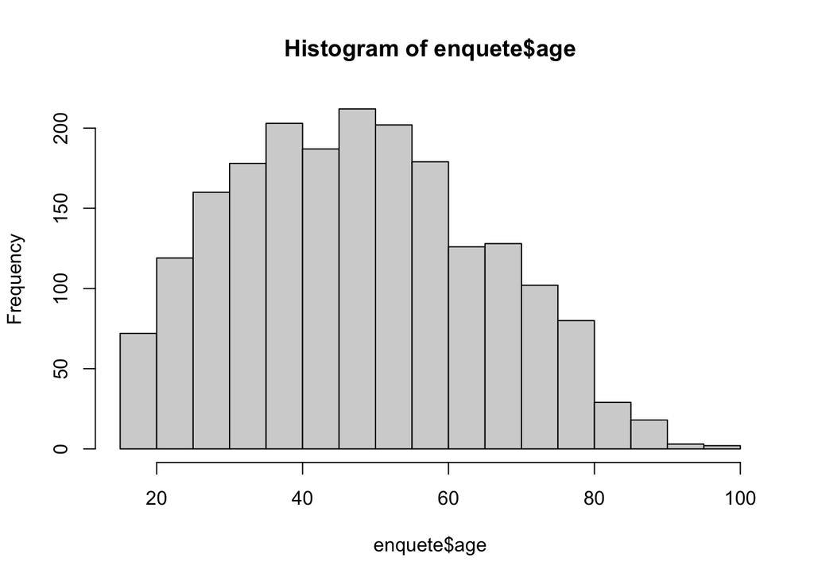

```r
hist(enquete$age)
```

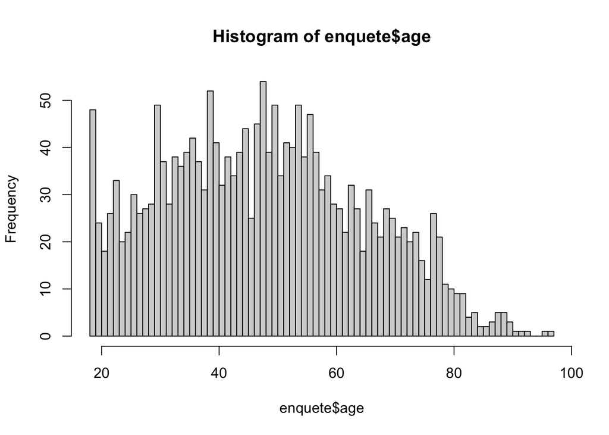

```r
# Personalisation du Histrogramme ----

# l'argument  `breaks`, qui permet d'indiquer le nombre de classes que l'on souhaite.

hist(enquete$age, breaks = 100)
```

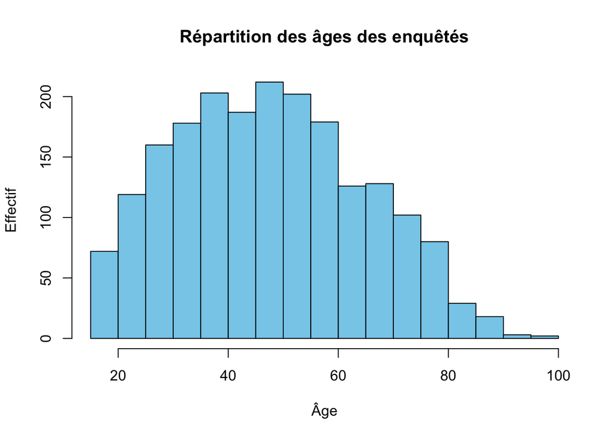

```r
# Labels
fig_1 <-
hist(enquete$age, col = "skyblue",
     main = "Répartition des âges des enquêtés",
     xlab = "Âge",
     ylab = "Effectif")
```

```r
fig_1
```

```
## $breaks
##  [1]  15  20  25  30  35  40  45  50  55  60  65  70  75  80  85  90  95 100
##
## $counts
##  [1]  72 119 160 178 203 187 212 202 179 126 128 102  80  29  18   3   2
##
## $density
##  [1] 0.0072 0.0119 0.0160 0.0178 0.0203 0.0187 0.0212 0.0202 0.0179 0.0126
## [11] 0.0128 0.0102 0.0080 0.0029 0.0018 0.0003 0.0002
##
## $mids
##  [1] 17.5 22.5 27.5 32.5 37.5 42.5 47.5 52.5 57.5 62.5 67.5 72.5 77.5 82.5 87.5
## [16] 92.5 97.5
##
## $xname
## [1] "enquete$age"
##
## $equidist
## [1] TRUE
##
## attr(,"class")
## [1] "histogram"
```

# Data Frames

```r
df<-data.frame(subject=as.factor(c("Pierre","Anne","Joyce","Peter","Alan","Camille")), age=as.numeric(c(20, 16, 19, 99, 23, 18)), sex=as.factor(c("M","F","F","M",NA,"F")), height=as.numeric(c(172, 181, 165, 168, 177, 178)), speed=as.numeric(c(11.20,3.00,11.50,10.35,10.98,13.05)))
```

Check the data.frame df by simply typing in:

```r
df
```

```
##   subject age  sex height speed
## 1  Pierre  20    M    172 11.20
## 2    Anne  16    F    181  3.00
## 3   Joyce  19    F    165 11.50
## 4   Peter  99    M    168 10.35
## 5    Alan  23 <NA>    177 10.98
## 6 Camille  18    F    178 13.05
```

Because the data are not that big you are able to view them entirely in your R studio. However, if you have very big data you may want to view only the first lines:

```r
head(df, 4)
```

```
##   subject age sex height speed
## 1  Pierre  20   M    172 11.20
## 2    Anne  16   F    181  3.00
## 3   Joyce  19   F    165 11.50
## 4   Peter  99   M    168 10.35
```

To inspect the structure of the data:

```r
str(df)
```

```
## 'data.frame':    6 obs. of  5 variables:
##  $ subject: Factor w/ 6 levels "Alan","Anne",..: 6 2 4 5 1 3
##  $ age    : num  20 16 19 99 23 18
##  $ sex    : Factor w/ 2 levels "F","M": 2 1 1 2 NA 1
##  $ height : num  172 181 165 168 177 178
##  $ speed  : num  11.2 3 11.5 10.3 11 ...
```

Some basic statistics can be given by the summary command:

```r
summary(df)
```

```
##     subject       age          sex        height          speed
##  Alan   :1   Min.   :16.00   F   :3   Min.   :165.0   Min.   : 3.00
##  Anne   :1   1st Qu.:18.25   M   :2   1st Qu.:169.0   1st Qu.:10.51
##  Camille:1   Median :19.50   NA's:1   Median :174.5   Median :11.09
##  Joyce  :1   Mean   :32.50            Mean   :173.5   Mean   :10.01
##  Peter  :1   3rd Qu.:22.25            3rd Qu.:177.8   3rd Qu.:11.43
##  Pierre :1   Max.   :99.00            Max.   :181.0   Max.   :13.05
```

### Missing values

To examine if missing values (NA) are in the data:

```r
is.na(df)
```

```
##      subject   age   sex height speed
## [1,]   FALSE FALSE FALSE  FALSE FALSE
## [2,]   FALSE FALSE FALSE  FALSE FALSE
## [3,]   FALSE FALSE FALSE  FALSE FALSE
## [4,]   FALSE FALSE FALSE  FALSE FALSE
## [5,]   FALSE FALSE  TRUE  FALSE FALSE
## [6,]   FALSE FALSE FALSE  FALSE FALSE
```

If you want the row and column index where NAs occur:

```r
which(is.na(df), arr.ind=T)
```

```
##      row col
## [1,]   5   3
```

### Impossible extreme values

We can use boxplots to see if there are impossible extreme values:

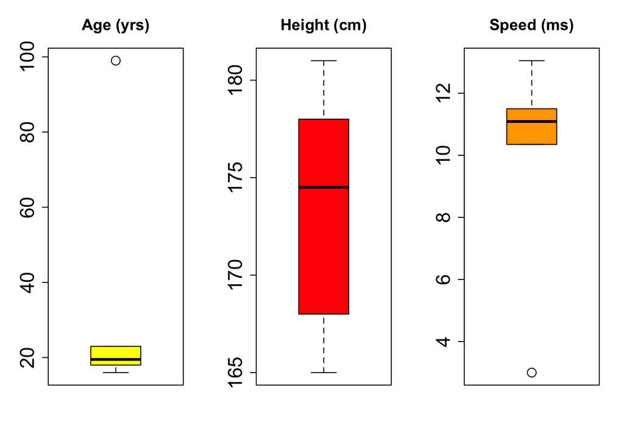

```r
par(mfrow=c(1,3))
boxplot(df$age, main="Age (yrs)", cex.lab=2.0, cex.axis=2.0, cex.main=1.6, cex=2.0, col="yellow")
boxplot(df$height, main="Height (cm)", cex.lab=2.0, cex.axis=2.0, cex.main=1.6, cex=2.0, col="red")
boxplot(df$speed, main="Speed (ms)", cex.lab=2.0, cex.axis=2.0, cex.main=1.6, cex=2.0, col="orange")
```

### Finding & replacing the extreme values manually

Compute the mean *before* the removal of outliers:

```r
mean(df$age)
```

```
## [1] 32.5
```

Check if there are cases that are older than 40 years:

```r
df$age>40
```

```
## [1] FALSE FALSE FALSE  TRUE FALSE FALSE
```

Replace the case(s) older than 40 with a missing value (NA).

```r
df$age[df$age>40]<-NA
```

Compute again the mean age, allowing to remove missing values (NAs):

```r
mean(df$age, na.rm=TRUE)
```

```
## [1] 19.2
```

### Inspecting mean age for male and female participants

Mean age for male and female participants.

```r
aggregate(age ~ sex, data=df, FUN=mean, na.rm=TRUE)
```

```
##   sex      age
## 1   F 17.66667
## 2   M 20.00000
```

### Inspecting relations between variables

Use a scatterplot to display the relation between age and speed:

[figure not shown]

```r
par(mfrow=c(1,1))
plot(speed ~ age, data=df, col="blue", pch=1, cex=1.2)
```

# QUIZ QUESTIONS AND ANSWERS

### Quiz Question I

Replace the outlier of 3.00 ms in the variable *df$speed* with a NA.

**Answer** There are multiple solutions possible:

```r
df$speed[df$speed==3.00]<-NA
```

Another solution:

```r
df[2,5]<-NA
```

To verify that the value was indeed replaced by a NA use the command `is.na`:

```r
is.na(df$speed)
```

```
## [1] FALSE  TRUE FALSE FALSE FALSE FALSE
```

### Quiz Question II

A dataset could erroneously have double records (duplicates). This is bad and should be removed.

Seeing the current dataset, what would be a way to discover duplicates in the variable *df$subject*?

Check your solution for the following data.frame that contains double data:

```r
df<-data.frame(subject=as.factor(c("Pierre","Anne","Joyce","Peter","Alan","Camille", "Pierre")), age=as.numeric(c(20, 16, 19, 99, 23, 18, 20)), sex=as.factor(c("M","F","F","M",NA,"F", "M")), height=as.numeric(c(172, 181, 165, 168, 177, 178, 172)), speed=as.numeric(c(11.20,3.00,11.50,10.35,10.98,13.05, 11.20)))
```

**Answer**

A way to inspect for double records is to use the `table` function.

```r
table(df$subject)
```

```
##
##    Alan    Anne Camille   Joyce   Peter  Pierre
##       1       1       1       1       1       2
```

But still simpler, using the `summary` function would also display this:

```r
summary(df)
```

```
##     subject       age          sex        height          speed
##  Alan   :1   Min.   :16.00   F   :3   Min.   :165.0   Min.   : 3.00
##  Anne   :1   1st Qu.:18.50   M   :3   1st Qu.:170.0   1st Qu.:10.66
##  Camille:1   Median :20.00   NA's:1   Median :172.0   Median :11.20
##  Joyce  :1   Mean   :30.71            Mean   :173.3   Mean   :10.18
##  Peter  :1   3rd Qu.:21.50            3rd Qu.:177.5   3rd Qu.:11.35
##  Pierre :2   Max.   :99.00            Max.   :181.0   Max.   :13.05
```

```r
library(questionr)
data(hdv2003)
```

[^1]: `c` est l’abbréviation de *combine*, son nom est très court car on l’utilise très souvent